# Presentation Exercise

### Create a graph

I choose to reproduce a graph in the ariticle [“Be Suspicious Of Online Movie Ratings, Especially Fandango’s”](https://fivethirtyeight.com/features/fandango-movies-ratings/) from FiveThirtyEight. The graph is shown below:

[figure not shown]

I first sent the graph to ChatGPT and asked it to re-create the original graph. Here’s the initial code I received to make the graph.

```r
# Load necessary libraries
library(ggplot2)
library(dplyr)
library(tidyr)

# Load dataset
score <- read.csv("fandango_score_comparison.csv")

# Create a dataframe with normalized scores
score_normalized <- score %>%
  select(Fandango_Stars, RT_norm_round, RT_user_norm_round, Metacritic_norm_round, Metacritic_user_norm_round, IMDB_norm_round) %>%
  gather(key = "Source", value = "Rating")  # Reshape data to long format

# Create the plot
ggplot(score_normalized, aes(x = Rating, fill = Source)) +
  geom_density(alpha = 0.6) +
  scale_fill_manual(values = c("Fandango_Ratingvalue" = "red",
                               "IMDB_norm_round" = "yellow",
                               "Metacritic_norm_round" = "green",
                               "RT_norm_round" = "blue",
                               "RT_user_norm_round" = "lightblue",
                               "Metacritic_user_norm_round" = "lightgreen")) +
  theme_minimal() +
  labs(title = "Fandango LOVES Movies",
       subtitle = "Normalized ratings distribution of films in theaters in 2015",
       x = "Normalized Rating",
       y = "Density") +
  theme(legend.position = "top") +
  scale_x_continuous(breaks = seq(0, 5, by = 0.5)) +
  theme(legend.title = element_blank())
```

[figure not shown]

The graph is not similar to the original one, so I used some prompts to let ChatGPT revise the code: Use percentage as y axis; Discrete points that are connected by straight lines instead of smooth curves; Use use geom_ribbon to create shadows under each line. After iterations, I got the code as below:

```r
# Load necessary libraries
library(ggplot2)
library(dplyr)
library(tidyr)

# Load dataset
score <- read.csv("fandango_score_comparison.csv")

# Create a dataframe with normalized scores
score_normalized <- score %>%
  select(Fandango_Stars, RT_norm_round, RT_user_norm_round, Metacritic_norm_round, Metacritic_user_norm_round, IMDB_norm_round) %>%
  gather(key = "Source", value = "Rating")  # Reshape data to long format

# Create a count of ratings for each source
rating_counts <- score_normalized %>%
  group_by(Source, Rating) %>%
  summarise(count = n(), .groups = "drop") %>%  # Avoid the grouped output warning
  ungroup() %>%
  group_by(Source) %>%
  mutate(percentage = count / sum(count) * 100)  # Convert to percentage

# Extend the data to include the full range of x-axis
rating_counts_extended <- rating_counts %>%
  complete(Rating = seq(0.5, 5, by = 0.5), fill = list(count = 0)) %>%
  group_by(Source) %>%
  mutate(percentage = count / sum(count) * 100)  # Recalculate percentage after filling

# Define color palette for the shaded areas (to match the original graph)
colors <- c("Fandango_Stars" = "red",
            "IMDB_norm_round" = "yellow",
            "Metacritic_norm_round" = "green",
            "RT_norm_round" = "blue",
            "RT_user_norm_round" = "lightblue",
            "Metacritic_user_norm_round" = "lightgreen")

# Create the plot with shaded areas beneath the lines using geom_ribbon
ggplot(rating_counts_extended, aes(x = Rating, y = percentage, group = Source, fill = Source)) +
  geom_ribbon(aes(ymin = 0, ymax = percentage), alpha = 0.4) +  # Add ribbon for shadow effect
  geom_line(size = 1) +  # Sharp lines
  scale_x_continuous(breaks = seq(0, 5, by = 0.5)) +  # X-axis breaks at 0.5 intervals
  scale_fill_manual(values = colors) +  # Use the custom color palette for the fill
  scale_color_manual(values = colors) +  # Use the same color for lines
  theme_minimal() +
  labs(title = "Fandango LOVES Movies",
       subtitle = "Normalized ratings distribution of films in theaters in 2015",
       x = "Normalized Rating",
       y = "Percentage") +
  theme(legend.position = "top") +
  theme(legend.title = element_blank()) +  # Clean up legend
  expand_limits(x = c(0.5, 5))  # Extend the x-axis range
```

[figure not shown]

Now it looks almost good, and then I will make modifications manually to make it more similar to the original graph.

```r
# Load necessary libraries
library(ggplot2)
library(dplyr)
library(tidyr)
library(ggthemes)

# Load dataset
score <- read.csv("fandango_score_comparison.csv")

# Create a dataframe with normalized scores
score_normalized <- score %>%
  select(Fandango_Stars, RT_norm_round, RT_user_norm_round, Metacritic_norm_round, Metacritic_user_norm_round, IMDB_norm_round) %>%
  gather(key = "Source", value = "Rating")  # Reshape data to long format

# Create a count of ratings for each source
rating_counts <- score_normalized %>%
  group_by(Source, Rating) %>%
  summarise(count = n(), .groups = "drop") %>%  # Avoid the grouped output warning
  ungroup() %>%
  group_by(Source) %>%
  mutate(percentage = count / sum(count) * 100)  # Convert to percentage

# Extend the data to include the full range of x-axis
rating_counts_extended <- rating_counts %>%
  complete(Rating = seq(0.5, 5, by = 0.5), fill = list(count = 0)) %>%
  group_by(Source) %>%
  mutate(percentage = count / sum(count) * 100)  # Recalculate percentage after filling

# Define color palette for both the ribbons and the lines to match
colors_line <- c("Fandango_Stars" = "#fb4d2f",
            "IMDB_norm_round" = "#f4c026",
            "Metacritic_norm_round" = "#a04f9c",
            "RT_norm_round" = "#6a6a6a",
            "RT_user_norm_round" = "#37a4da",
            "Metacritic_user_norm_round" = "#aeca92")

colors_fill <- c("Fandango_Stars" = "#fb4d2f",
            "IMDB_norm_round" = "#6a6a6a",
            "Metacritic_norm_round" = "#6a6a6a",
            "RT_norm_round" = "#6a6a6a",
            "RT_user_norm_round" = "#6a6a6a",
            "Metacritic_user_norm_round" = "#6a6a6a")

# Create a custom label map
label_map <- c("Fandango_Stars" = "Fandango",
               "RT_norm_round" = "Rotten Tomatoes",
               "RT_user_norm_round" = "Rotten Tomatoes users",
               "Metacritic_norm_round" = "Metacritic",
               "Metacritic_user_norm_round" = "Metacritic users",
               "IMDB_norm_round" = "IMDb users")

# Add hjust and vjust columns to control text label positioning
rating_counts_extended <- rating_counts_extended %>%
  mutate(
    hjust = case_when(
      Source == "Fandango_Stars" ~ -0.3,
      Source == "IMDB_norm_round" ~ 1.2,
      Source == "Metacritic_norm_round" ~ 4,
      Source == "RT_norm_round" ~ 5.5,
      Source == "RT_user_norm_round" ~ 2.2,
      Source == "Metacritic_user_norm_round" ~ 1.2
    ),
    vjust = case_when(
      Source == "Fandango_Stars" ~ 1.5,
      Source == "IMDB_norm_round" ~ 1.5,
      Source == "Metacritic_norm_round" ~ 2,
      Source == "RT_norm_round" ~ 1.5,
      Source == "RT_user_norm_round" ~ 1.8,
      Source == "Metacritic_user_norm_round" ~ 1.5
    )
  )

# Create the plot with shaded areas beneath the lines using geom_ribbon
ggplot(rating_counts_extended, aes(x = Rating, y = percentage, group = Source, fill = Source, color = Source)) +
  geom_ribbon(aes(ymin = 0, ymax = percentage), alpha = 0.3) +  # Add ribbon for shadow effect
  geom_line(size = 0.5) +  # Sharp lines for each source
  scale_x_continuous(breaks = seq(0, 5)) +  # X-axis breaks at 0.5 intervals
  scale_fill_manual(values = colors_fill) +  # Use the custom color palette for the fill
  scale_color_manual(values = colors_line) +  # Ensure the lines share the same colors as the ribbons
  theme_minimal() +
  theme_fivethirtyeight()+
  labs(title = "Fandango LOVES Movies",
       subtitle = "Normalized ratings distribution of 146 films in theaters in 2015 that
had 30+ reviews on Fandango.com",
       x="",
       y = "Percentage") +
  theme(legend.position = "none",  # Hide the legend
    plot.title = element_text(size = 18, face = "bold", color = "black", hjust = 0),
    # Title settings
    plot.subtitle = element_text(size = 14, color = "black", hjust = 0),
    # Subtitle settings
    plot.margin = margin(20, 20, 20, 20)  # Adjust plot margin
    ) +  # Hide the legend
  expand_limits(x = c(0, 5)) +  # Extend the x-axis range
  # Add custom labels near the peak of each line with correct colors
  geom_text(data = rating_counts_extended %>%
              group_by(Source) %>%
              slice(which.max(percentage)),  # Take the highest point for each line
            aes(label = label_map[Source], color = Source, hjust = hjust, vjust = vjust),
            size = 3)
```

[figure not shown]

Here’ the original graph for comparison:

[figure not shown]

Overall, the reproduced graph is similar to the original one, despite some imperfections, like the x-axis being numbers instead of the star images in the original graph.

### Create a table

I use the prompts below to let ChatGPT generate table for me: Make table showing summary statistics such as mean, median, min, max of the Fandango_Stars, RT_norm_round, RT_user_norm_round, Metacritic_norm_round, Metacritic_user_norm_round, IMDB_norm_round. * Bold the column headers for Mean (SD), Median (Q1, Q3), Min, and Max. * Highlight the “Mean (SD)” cell specifically for the Fandango platform. * Additional text outside of the regular table structure like spanning column headers or correctly attributed footnotes * A descriptive caption explaining the useful information summary that the table represents. Since I tried for a few hours and ChatGPT still could not add a column of sparklines for me, I made plots of distribution separately and saved them as pictures and then inserted them into the column.

Summary Statistics for Movie Rating Platforms

Comparison of Ratings on Different Platforms

Platform

**Summary Statistics**

Distribution

Mean (SD)<sup>1</sup>

Median (Q1, Q3)

Min

Max

Fandango

4.09 (0.54)

4 (3.5, 4.5)

3.0

5.0

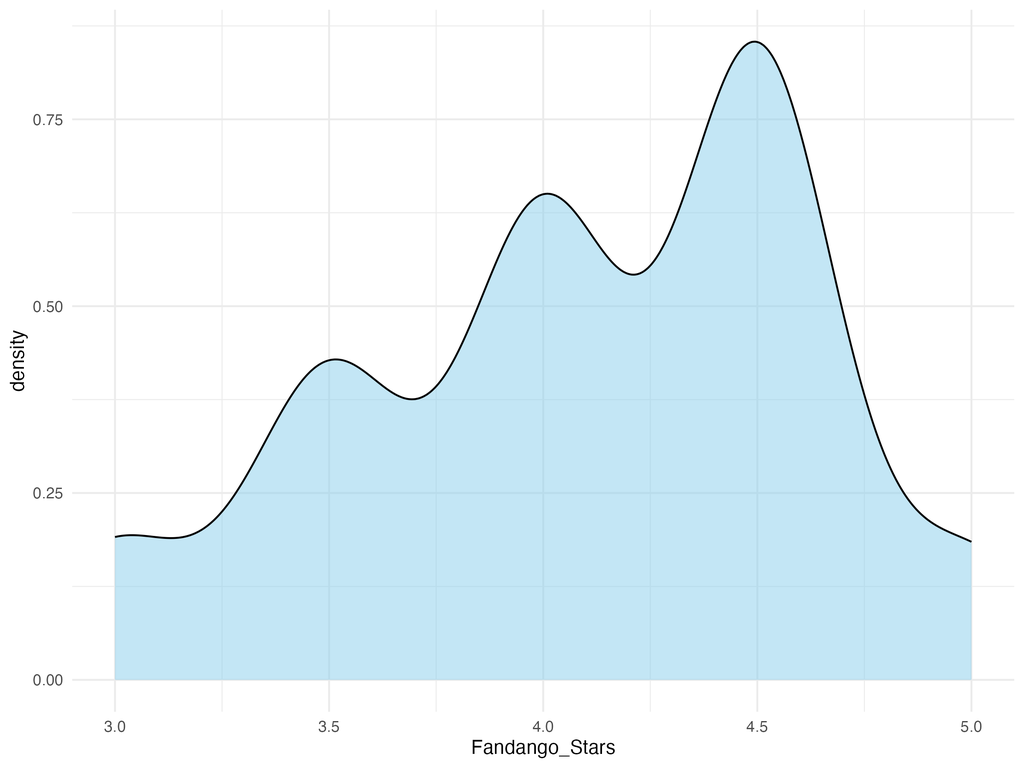

Rotten Tomatoes

3.07 (1.51)

3 (1.5, 4.5)

0.5

5.0

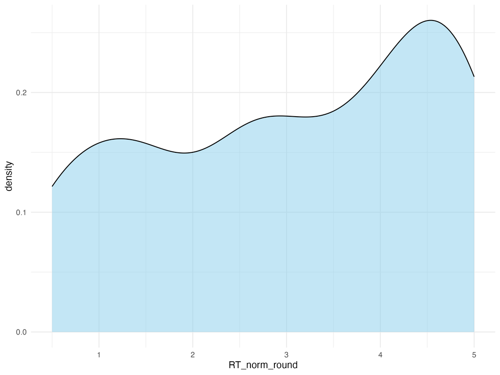

Rotten Tomatoes users

3.23 (1.01)

3.5 (2.5, 4)

1.0

4.5

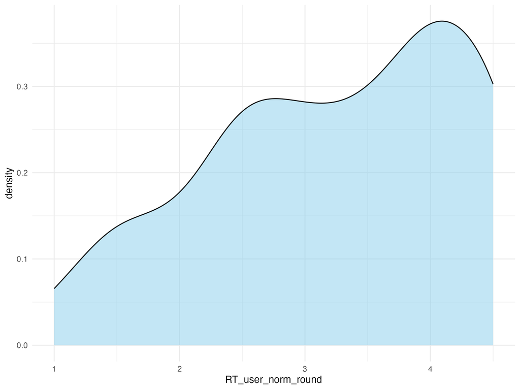

Metacritic

2.97 (0.99)

3 (2.12, 4)

0.5

4.5

[figure not shown]

Metacritic users

3.27 (0.79)

3.5 (3, 4)

1.0

5.0

[figure not shown]

IMDb users

3.38 (0.5)

3.5 (3, 3.5)

2.0

4.5

[figure not shown]

**Table 1 caption:** This table compares summary statistics like mean, median, min, and max for ratings across various platforms.

<sup>1</sup> Summary statistics (mean, median, min, max) for different movie rating platforms.

```r
# Load libraries
#library(kableExtra)
library(gt)
library(dplyr)

# Read the data
data <- read.csv("fandango_score_comparison.csv")

# Descriptive platform names
platform_names <- c(
  "Fandango_Stars" = "Fandango",
  "RT_norm_round" = "Rotten Tomatoes",
  "RT_user_norm_round" = "Rotten Tomatoes users",
  "Metacritic_norm_round" = "Metacritic",
  "Metacritic_user_norm_round" = "Metacritic users",
  "IMDB_norm_round" = "IMDb users"
)

# List of variables to plot
variables <- c("Fandango_Stars", "RT_norm_round", "RT_user_norm_round",
               "Metacritic_norm_round", "Metacritic_user_norm_round", "IMDB_norm_round")

# Function to generate and save distribution plots
generate_distribution_plots <- function(variable) {
  # Create the plot (density plot in this case)
  p <- ggplot(data, aes_string(x = variable)) +
    geom_density(fill = "skyblue", alpha = 0.5) +
    theme_minimal()

  # Save the plot as PNG
  file_name <- paste0( variable, "_distribution.png")
  ggsave(file_name, plot = p, width = 8, height = 6)

  # Return the file path
  return(file_name)
}

# Generate and save the distribution plots for each variable
plot_paths <- sapply(variables, generate_distribution_plots)
# Function to generate image file paths (replace with real image paths)
generate_image_path <- function(platform_name) {
  # For demonstration, I use a placeholder image name (replace with your actual images)
  image_urls <- c(
    "Fandango" = "Fandango_Stars_distribution.png",
    "Rotten Tomatoes" = "RT_norm_round_distribution.png",
    "Rotten Tomatoes users" = "RT_user_norm_round_distribution.png",
    "Metacritic" = "IMDB_norm_round_distribution.png",
    "Metacritic users" = "Metacritic_norm_round_distribution.png",
    "IMDb users" = "Metacritic_user_norm_round_distribution.png"
  )

  return(image_urls[platform_name])
}

# Compute summary statistics for each platform
summary_stats <- data %>%
  summarise(
    `Platform` = platform_names["Fandango_Stars"],
    `Mean (SD)` = paste0(round(mean(Fandango_Stars), 2), " (", round(sd(Fandango_Stars), 2), ")"),
    `Median (Q1, Q3)` = paste0(round(median(Fandango_Stars), 2), " (",
                               round(quantile(Fandango_Stars, 0.25), 2), ", ",
                               round(quantile(Fandango_Stars, 0.75), 2), ")"),
    Min = round(min(Fandango_Stars), 2),
    Max = round(max(Fandango_Stars), 2),
    Distribution = generate_image_path("Fandango")  # Add image path for Fandango
  )

# Platforms for which summary statistics are needed
platforms <- c("RT_norm_round", "RT_user_norm_round", "Metacritic_norm_round",
               "Metacritic_user_norm_round", "IMDB_norm_round")

# Compute summary statistics for each platform and append them
for (platform in platforms) {
  stats <- data %>%
    summarise(
      `Platform` = platform_names[platform],
      `Mean (SD)` = paste0(round(mean(get(platform)), 2), " (", round(sd(get(platform)), 2), ")"),
      `Median (Q1, Q3)` = paste0(round(median(get(platform)), 2), " (",
                                 round(quantile(get(platform), 0.25), 2), ", ",
                                 round(quantile(get(platform), 0.75), 2), ")"),
      Min = round(min(get(platform)), 2),
      Max = round(max(get(platform)), 2),
      Distribution = generate_image_path(platform_names[platform])  # Add image path for each platform
    )

  # Append the stats to summary_stats
  summary_stats <- bind_rows(summary_stats, stats)
}

# Create the table with summary statistics and image column
final_table <- summary_stats %>%
  gt() %>%
  # Adding header that spans multiple columns
  tab_header(
    title = "Summary Statistics for Movie Rating Platforms",
    subtitle = "Comparison of Ratings on Different Platforms"
  ) %>%
  tab_spanner(
    label = md("**Summary Statistics**"),
    columns = c(`Mean (SD)`, `Median (Q1, Q3)`, Min, Max)
  ) %>%
  # Adding a descriptive footnote for statistics
  tab_footnote(
    footnote = md("Summary statistics (mean, median, min, max) for different movie rating platforms."),
    locations = cells_column_labels(columns = `Mean (SD)`)
  ) %>%
  # Adding a source note with explanation
  tab_source_note(
    source_note = md("**Table 1 caption:** This table compares summary statistics like mean, median, min, and max for ratings across various platforms.")
  ) %>%
  # Bold specific column labels: Mean (SD), Median (Q1, Q3), Min, Max
  tab_style(
    style = cell_text(weight = "bold"),
    locations = cells_column_labels(columns = c("Mean (SD)", "Median (Q1, Q3)", "Min", "Max"))
  ) %>%
  # Highlighting the "Mean (SD)" cell for "Fandango"
  tab_style(
    style = cell_fill(color = "lightblue"),  # Highlight color
    locations = cells_body(
      rows = summary_stats$Platform == "Fandango",  # Targeting Fandango row
      columns = "Mean (SD)"
    )
  ) %>%
  # Displaying images in the new 'Image' column
  fmt_image(
    columns = "Distribution",
    rows = everything(),
    path = NULL,  # Path is not required if you're using URLs
    file_pattern = "{x}",
    encode = TRUE
  )

# Display the table
final_table
```